# One-Class Classification

Jimmy Azar

Here I implement a one-class classifier based on a self-organizing map (SOM). This classifier clusters the training data into $k$ clusters, and then measures the distance from any test object location to the nearest cluster center; if the distance is above a threshold, then the object is labeled as an outlier, otherwise it is labeled as in inlier.

The classifier requires setting the parameter `gridSize`, where the number of clusters will be $k = $ gridSize $\times$ gridSize, as well as the parameter `fracrej` which represents the fraction of training objects to reject.

Two datasets are used for testing the classifier: (i) an artificial 2D dataset consisting for two Gaussian blobs at a distance from each other, forming the target class and (ii) a dataset consisting of boomerang-shaped branches.

# SOM One-Class Classifier

The SOM one-class classifier relies on Kohonen’s self-organizing map in order to cluster the training data. Neighboring cluster centers in a $p$-dimensional data space are also neighbors in map space which is usually 2- or 3-dimensional to allow visualization.

After clustering the data into $k$ clusters, the distance, $d$, from each test object to the nearest cluster center is computed and the object is labeled relative to a threshold determined by the parameter `fracrej`.

The parameter `fracrej` corresponds to a certain threhsold. The threshold $\theta$ is defined to reject a certain fraction of the training set: `fracrej` $\in [0,1]$. This parameter is optimized using an ROC curve over a validation set.

$$Label(x) = \begin{cases}
target, & \text{if } d \leq \theta \\
outlier, & \text{if } d > \theta \\
\end{cases}$$

## Dataset Generation

```r
gausscirc <- function(ntrn_inlier=100, ntst_inlier=20, ntst_outlier=20, show=TRUE, seed=1){
#Generates two circularly symmetric Gaussian distributions in 2D with zero mean and with the identity matrix as covariance matrix.
#The training set consists only of inliers; their number is ntrn_inliers objects per distribution.
#The test set may consists of inliers (ntst_inlier objects per distribution) and should consist of outliers (ntst_outlier objects per distribution) drawn randomly from a uniform distribution.
#Inliers are assumed to have a '0' label while outliers have a '1' label.

  if (!require("MASS")) install.packages("MASS")
  library("MASS")

  #generate training inliers
  set.seed(seed)
  x <- 0.3*mvrnorm(ntrn_inlier, mu = c(0,0), Sigma = matrix(c(1,0,0,1),nrow = 2))
  xin <- rbind(x+2,x-2)
  xin <- cbind(xin,rep(0,ntrn_inlier)) #add '0' labels for inliers

  #generate test inliers (if any)
  if (ntst_inlier!=0){
    set.seed(seed+1)
    z <- 0.3*mvrnorm(ntst_inlier, mu = c(0,0), Sigma = matrix(c(1,0,0,1),nrow = 2))
    zin <- rbind(z+2,z-2)
    zin <- cbind(zin,rep(0,ntst_inlier)) #add '0' labels for inliers
  }
  else{zin <- numeric(0)}

  #generate test outliers from uniform distribution between [-5,5]
  set.seed(seed)
  f1 <- runif(ntst_outlier, min = -5, max = 5) #uniform distribution for feature 1
  set.seed(seed+1)
  f2 <- runif(ntst_outlier, min = -5, max = 5) #uniform distribution for feature 2
  zout <- cbind(f1,f2,rep(1,ntst_outlier))

  xtrn <- as.data.frame(xin)
  colnames(xtrn) <- c("f1","f2","label")

  xtst <- as.data.frame(rbind(zin,zout))
  colnames(xtst) <- c("f1","f2","label")

  if(show){
    plot(xin, col="blue", pch=20, xlab = "feature 1", ylab = "feature 2",
         xlim = c(-5.2,5.2), ylim = c(-5.2,5.2))
    points(zin,pch=20,col="violetred")
    points(zout,pch=17,col="violetred")
    legend("bottomright",legend = c("training inlier","test inlier","test outlier"),
           col = c("blue","violetred","violetred"), pch = c(20,20,17), cex=0.8)
  }

  l = list(xtrn,xtst) #create list of outputs
  return(l)
}
```

A second 2D artificial dataset is used which consists of two boomerang-shaped branches. The training set consists only of inliers. The test set may contain inliers and outliers. I have drawn the outliers randomly from a uniform distribution. Inliers are assumed to have a ‘0’ label while outliers have a ‘1’ label.

```r
boomerang <- function(Ntrn=c(50,50), Ntst = c(20,20), ntst_outlier=100, s=1,
                      show=TRUE,seed=1){
  #Generate a boomerang-shaped training set with the number of objects in each branch described by Ntrn.
  #The number on test set inliers in each branch is given by Ntst.
  #The number of test set outliers is ntst_outlier drawn randomly from a uniform distribution.
  #Parameter s controls the width of the branches.

  if (!require("MASS")) install.packages("MASS")
  library("MASS")

  r <- 5  #size of boomerang

  #generate training inliers
  set.seed(seed)
  domaina = 0.125*pi + runif(n = Ntrn[1], min = 0, max =1) * 1.25*pi
  t1 <- mvrnorm(n=Ntrn[1], mu = c(0,0), Sigma = matrix(c(1,0,0,1),nrow = 2))*s
  a <- cbind(r*sin(domaina),r*cos(domaina)) + t1

  domainb = 0.375*pi - runif(n = Ntrn[2], min = 0, max = 1) * 1.25*pi
  t2 <- mvrnorm(n = Ntrn[2], mu = c(0,0), Sigma = matrix(c(1,0,0,1),nrow = 2))*s
  b <-  cbind(r*sin(domainb),r*cos(domainb)) + t2 +
              matrix(c(-0.75*r,-0.75*r),nrow=Ntrn[2],ncol=2)

  #combine the two branches into a training set
  xin <- rbind(a,b)
  xin <- cbind(xin,rep(0,nrow(xin)))
  xtrn <- as.data.frame(xin)
  colnames(xtrn) <- c("f1","f2","label")

  #get boundary limits
  mn <- apply(xtrn[,1:2],2,min)
  mx <- apply(xtrn[,1:2],2,max)
  xmin <- mn[1]; ymin <- mn[2]
  xmax <- mx[1]; ymax <- mx[2]
  low <- min(xmin,ymin)-1 #add margin
  high <- max(xmax,ymax)+1 #add margin

  #generate test inliers (if any)
  if (sum(Ntst)!=0){
    set.seed(seed+1)
    domaina = 0.125*pi + runif(n = Ntst[1], min = 0, max =1) * 1.25*pi
    t1 <- mvrnorm(n=Ntst[1], mu = c(0,0), Sigma = matrix(c(1,0,0,1),nrow = 2))*s
    a <- cbind(r*sin(domaina),r*cos(domaina)) + t1

    domainb = 0.375*pi - runif(n = Ntst[2], min = 0, max = 1) * 1.25*pi
    t2 <- mvrnorm(n = Ntst[2], mu = c(0,0), Sigma = matrix(c(1,0,0,1),nrow = 2))*s
    b <- cbind(r*sin(domainb),r*cos(domainb)) + t2 +
         matrix(c(-0.75*r,-0.75*r),nrow=Ntst[2],ncol=2)

    zin <- rbind(a,b)
    zin <- cbind(zin,rep(0,nrow(zin))) #add labels '0'
  }
  else{zin <- numeric(0)}

  #generate test outliers from uniform distribution
  set.seed(seed+2)
  f1 <- runif(ntst_outlier, min = low, max = high) #uniform distribution for feature 1
  set.seed(seed+3)
  f2 <- runif(ntst_outlier, min = low, max = high) #uniform distribution for feature 2
  zout <- cbind(f1,f2,rep(1,ntst_outlier)) #add labels '1'

  #combine into a test set
  xtst <- as.data.frame(rbind(zin,zout))
  colnames(xtst) <- c("f1","f2","label")

  if(show){
    plot(xin,col="blue",pch=20,xlab = "feature 1", ylab = "feature 2",
         xlim = c(low,high), ylim = c(low,high))
    points(zin,pch=20,col="violetred") #add test set inliers
    points(zout,pch=17,col="violetred") #add test set outliers
    legend("bottomright",legend = c("training inlier","test inlier","test outlier"),
           col = c("blue","violetred","violetred"), pch = c(20,20,17), cex=0.8)
  }

  l = list(xtrn,xtst) #create list of outputs
  return(l)
}
```

## Classifier

```r
somocc <- function(xtrn, xtst, gridSize = 4, fracrej = 0.05, seed=1){
  #training set should contain inliers only
  #test set can contain inliers and outliers
  #set seed to fix the resulting centroids
  #number of clusters = gridSize x gridSize
  #fracrej is the fraction of training objects to reject.

  if (!require("rdist")) install.packages("rdist")
  if (!require("kohonen")) install.packages("kohonen")
  library("rdist")
  library("kohonen")

  set.seed(seed)
  tmp <- xtrn
  colnames(tmp) <- NULL
  trainDataMatrix <- as.matrix(tmp[,-ncol(tmp)])
  #Ensure outliers of training set are not used
  Ltrn <- xtrn[,ncol(xtrn)]
  trainDataMatrix <- trainDataMatrix[Ltrn==0,] #inliers

  som_grid <- somgrid(xdim = gridSize, ydim=gridSize, topo="hexagonal")
  som_model <- som(trainDataMatrix, grid=som_grid, rlen=100, alpha=c(0.05,0.01))
  centroids <- som_model$codes[[1]]

  trainDistMat <- t(cdist(centroids,trainDataMatrix,metric="euclidean"))
  trainDistMatOrder <- t(apply(trainDistMat,1,order,decreasing = FALSE))
  d <- diag(trainDistMat[,trainDistMatOrder[,1]]) #distance to nearest centroid

  # compute threshold equivalent to fracrej
  nf <- length(d)
  dSorted <- sort(d,decreasing = FALSE)
  nobj_acc <- round((1-fracrej)*nf)
  if (nobj_acc==0) thr <- 0
  else if (nobj_acc==nf) thr <- Inf
  else thr <- dSorted[nobj_acc]

  tmp <- xtst
  colnames(tmp) <- NULL
  testDataMatrix <- as.matrix(tmp[,-ncol(tmp)])
  testDistMat <- t(cdist(centroids,testDataMatrix,metric="euclidean"))
  testDistMatOrder <- t(apply(testDistMat,1,order,decreasing = FALSE))
  d <- diag(testDistMat[,testDistMatOrder[,1]]) #distance to nearest centroid

  #Label test set
  Ltst <- rep(0,nrow(xtst))
  Ltst[d > thr] <- 1 #assign as outlier

  l <- list(Ltst,centroids)
  return(l)
}
```

## Visualization of decision boundary

```r
viz <- function(data, resolution = 100, classifier, ...){
  #visualize decision boundary
  #data is labeled 2D dataset with labels as 3rd (last) column
  #grid resolution is 100 points per axis by default

  cl <- data[,3] #class labels; normally just training objects with label '0'
  kk <- length(unique(cl)) #number of classes
  color <- c("blue","violetred")
  shape <- c(20,17) #dot, triangle

  #find x-, y- limits of data
  mn <- apply(data[,1:2],2,min)
  mx <- apply(data[,1:2],2,max)
  xmin <- mn[1]; ymin <- mn[2]
  xmax <- mx[1]; ymax <- mx[2]
  low <- min(xmin,ymin)-3 #add margin
  high <- max(xmax,ymax)+3 #add margin

  #plot data objects in blue
  plot(data[,1:2],col = color[1], pch = shape[as.integer(cl)+1L],
       xlim = c(low,high),ylim = c(low,high),xlab("Feature 1"),ylab("Feature 2"))

  #set-up grid
  xs <- seq(low, high, length.out = resolution)
  ys <- seq(low, high, length.out = resolution)
  g <- cbind(rep(xs, each=resolution), rep(ys, time = resolution))
  g <- cbind(g, rep(0,nrow(g))) #add dummy labels
  g <- as.data.frame(g)
  colnames(g) <- colnames(data)

  #call classifier to predict grid point labels
  if (classifier == "gauss")  out <- gaussocc(data,g,...)
  else if (classifier == "parzen") out <- parzenocc(data,g,...)
  else if (classifier == "knn") out <- knnocc(data,g,...)
  else if (classifier == "rknnd") out <- rknndocc(data,g,...)
  else if (classifier == "kmeans") out <- kmeansocc(data,g,...)
  else if (classifier == "som") out <- somocc(data,g,...)
  else if (classifier == "gmm") out <- gmmocc(data,g,...)
  else message("Classifier specified is unknown!")
  L <- out[[1]]

  #plot grid points in colors reflecting their predicted labels
  points(g, col = color[as.integer(L)+1L], pch = ".")

  #add decision boundary contour
  z <- matrix(L+1L, nrow = resolution, byrow = TRUE)
  contour(xs, ys, z, add = TRUE, drawlabels = FALSE,
          lwd = 2, levels = (1:(kk-1))+.5)
}
```

## Demo

In this demo, I use all the above functions to show the resulting output for two artificial datasets: the first consisting of two separate Gaussian blobs, and the second consisting of two boomerang-shaped branches.

First, I call `gausscirc()` to generate a dataset.

```r
l <- gausscirc(ntrn_inlier = 200, ntst_inlier =  100, ntst_outlier = 100,
               show = TRUE, seed=1)
```

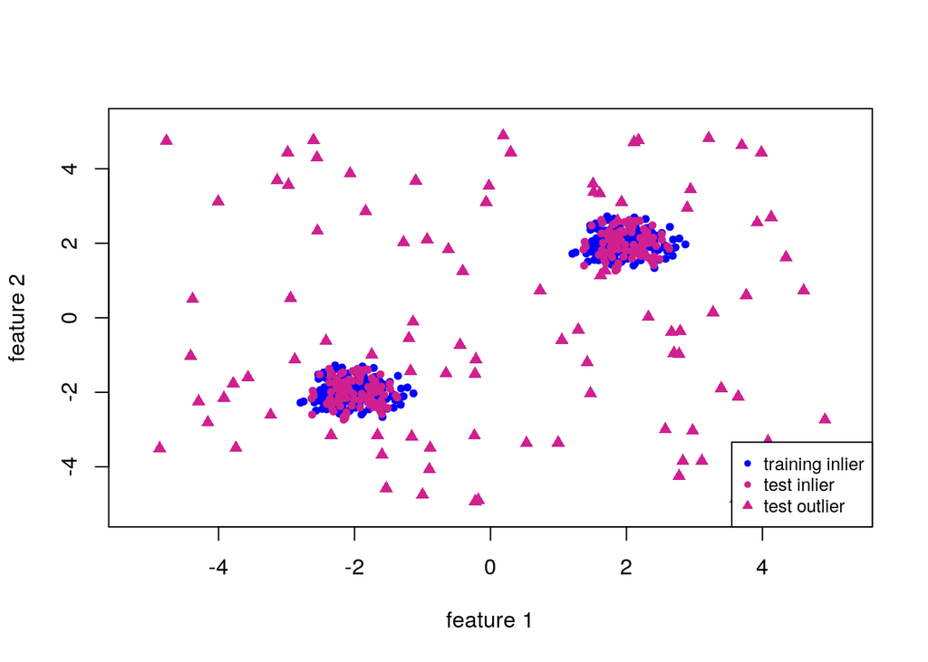

```r
xtrn <- l[[1]]
xtst <- l[[2]]
```

Set the gridSize parameter and visualize the clustering result.

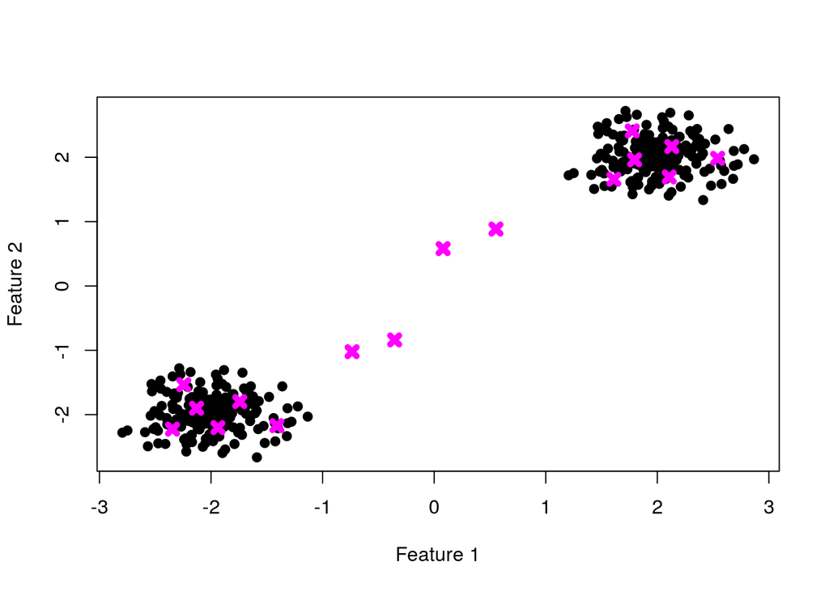

```r
#Visualize cluster centers
gridSize <- 4
l <- somocc(xtrn, xtst, gridSize = gridSize, fracrej = 0.05, seed = 1)
L <- l[[1]]
centroids <- l[[2]]

plot(xtrn[,1],xtrn[,2],pch=19, xlab="Feature 1",ylab="Feature 2")
points(centroids[,1],centroids[,2],pch=4,col="magenta",lwd=5)
```

I split the original test set into a validation set (for tuning the hyperparameter `fracrej`) and a final test set for assessing the performance of the classifier. The split I have selected is a random 50%-50% stratified split.

```r
#Split test set into validation set and final test set.
inliers <- which(xtst[,ncol(xtst)]==0)
outliers <- which(xtst[,ncol(xtst)]==1)
ind_in <- sample(inliers,floor(0.5*length(inliers))) #50% stratified split
ind_out <- sample(outliers,floor(0.5*length(outliers)))
xval <- xtst[c(ind_in,ind_out),]
xtst <- xtst[-c(ind_in,ind_out),]
```

For each possible value of `fracrej` in the range [0,1], train the classifier accordingly and compute the classification errors for inliers and outliers of the validation set.

```r
#Optimize fracrej parameter using validation set
#Optimize fracrej parameter using validation set
R <- seq(1,0,length.out = 500) #fracrej in [0,1]
error_inliers <- error_outliers <- numeric(0)
for (i in seq_along(R)){
  l <- somocc(xtrn,xval,gridSize=gridSize,fracrej = R[i],seed=1)
  L <- l[[1]]
  error_outliers[i] <- sum(L==0 & xval[,ncol(xval)]==1)
  error_inliers[i] <- sum(L==1 & xval[,ncol(xval)]==0)
}
```

Plot a receiver-operating characteristic (ROC) curve and select the optimal value for `fracrej` which corresponds to the point on the curve that is closest to the upper left corner of (0,1), i.e. perfect classification.

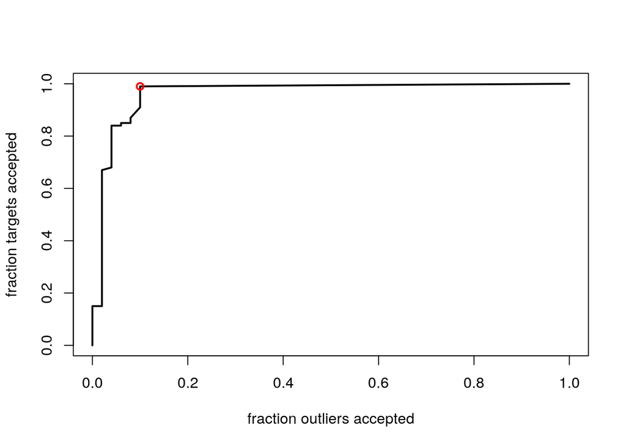

```r
#Plot ROC curve
y <- 1 - (error_inliers / sum(xval[,ncol(xval)]==0)) #frac targets accepted
x <- (error_outliers / sum(xval[,ncol(xval)]==1)) #frac outliers accepted
plot(x,y,type="l",lwd=2,xlab="fraction outliers accepted",ylab="fraction targets accepted") #ROC curve

#Find optimal point on ROC closest to upper left corner i.e. (0,1)
index <- which.min(x^2 + (y-1)^2)
points(x[index],y[index],pch=1,col="red",lwd=2)
```

```r
fracrej_opt <- R[index] #optimal fracrej
paste("Optimal fracrej =",fracrej_opt)
```

```
## [1] "Optimal fracrej = 0.00200400801603218"
```

Use the optimal value of `fracrej` to call the classifier once more and evaluate its performance on the final test set using a confusion matrix and the measures derived from it such as sensitivity, specificity, etc.

```r
#run optimal model and test
if (!require("e1071")) install.packages("e1071")
if (!require("caret")) install.packages("caret")
library(e1071)
library(caret)

#run optimal model and test
out <- somocc(xtrn, xtst, gridSize= gridSize, fracrej = fracrej_opt, seed=1)
pred <- out[[1]]
cf <- confusionMatrix(factor(pred,levels=c(0,1)),factor(xtst[,ncol(xtst)],levels=c(0,1)))
print(cf)
```

```
## Confusion Matrix and Statistics
##
##           Reference
## Prediction  0  1
##          0 99  6
##          1  1 44
##
##                Accuracy : 0.9533
##                  95% CI : (0.9062, 0.981)
##     No Information Rate : 0.6667
##     P-Value [Acc > NIR] : <2e-16
##
##                   Kappa : 0.8923
##
##  Mcnemar's Test P-Value : 0.1306
##
##             Sensitivity : 0.9900
##             Specificity : 0.8800
##          Pos Pred Value : 0.9429
##          Neg Pred Value : 0.9778
##              Prevalence : 0.6667
##          Detection Rate : 0.6600
##    Detection Prevalence : 0.7000
##       Balanced Accuracy : 0.9350
##
##        'Positive' Class : 0
##
```

Finally, visualize the training set and decision boundary of the classifier. Also add the test set objects with different markers for inliers and outliers.

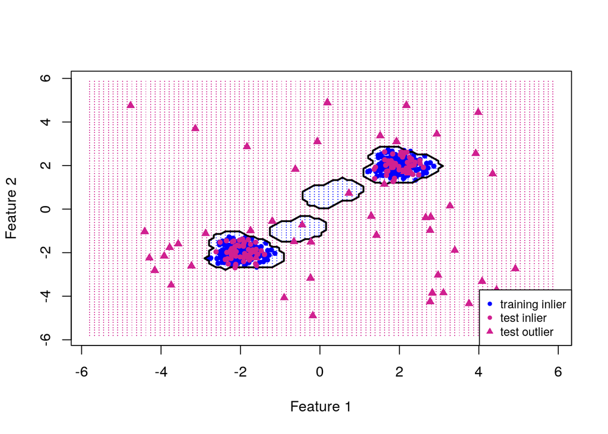

```r
#visualize decision boundary and training set
viz(data = xtrn, resolution = 100, classifier = "som",
    gridSize = gridSize, fracrej = fracrej_opt, seed = 1)

#add final test objects (inliers and outliers)
shape <- c(20,17) #dot, triangle
points(xtst[,1:2],col="violetred",pch=shape[xtst[,3]+1]) #add test objects
legend("bottomright",legend = c("training inlier","test inlier","test outlier"),
       col = c("blue","violetred","violetred"), pch = c(20,20,17), cex=0.8)
```

For the second dataset, I call `boomerang()` to generate a dataset.

```r
l <- boomerang(Ntrn = c(200,200), Ntst = c(100,100), ntst_outlier = 200, s=0.7,
               show =TRUE, seed=1)
```

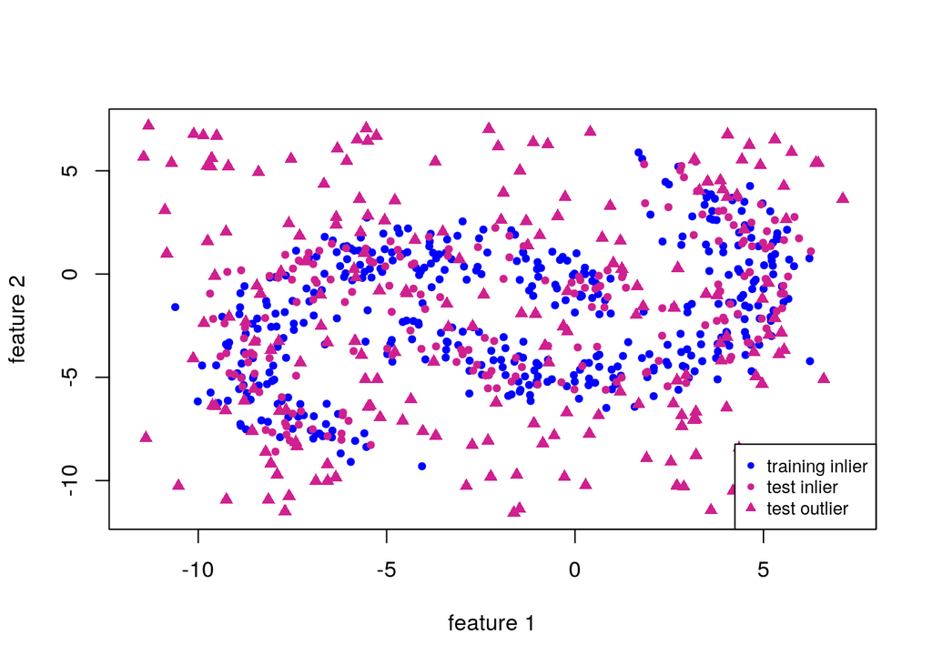

```r
xtrn <- l[[1]]
xtst <- l[[2]]
```

Set the gridSize parameter and visualize the clustering result.

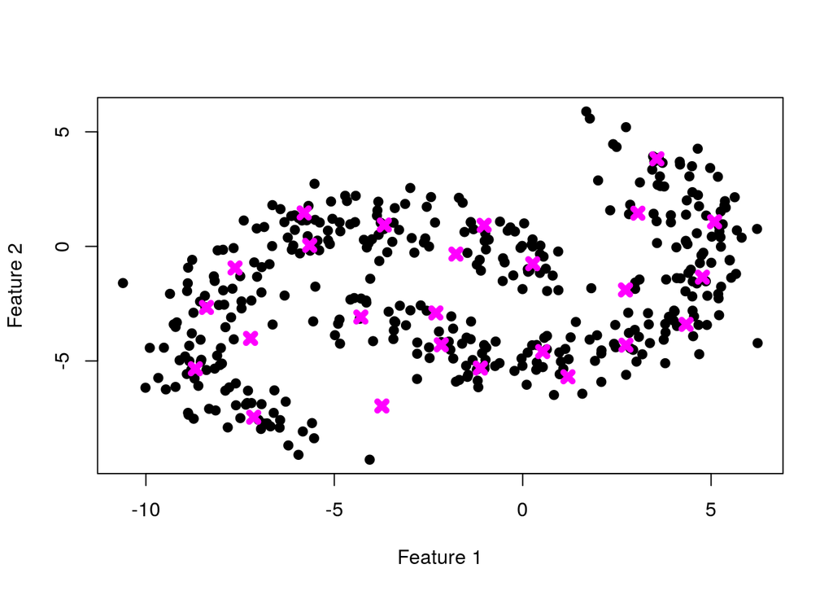

```r
#Visualize cluster centers
gridSize <- 5
l <- somocc(xtrn, xtst, gridSize = gridSize, fracrej = 0.05, seed = 1)
L <- l[[1]]
centroids <- l[[2]]

plot(xtrn[,1],xtrn[,2],pch=19, xlab="Feature 1",ylab="Feature 2")
points(centroids[,1],centroids[,2],pch=4,col="magenta",lwd=5)
```

I split the original test set into a validation set (for tuning the hyperparameter `fracrej`) and a final test set for assessing the performance of the classifier. The split I have selected is a random 50%-50% stratified split.

```r
#Split test set into validation set and final test set.
inliers <- which(xtst[,ncol(xtst)]==0)
outliers <- which(xtst[,ncol(xtst)]==1)
ind_in <- sample(inliers,floor(0.5*length(inliers))) #50% stratified split
ind_out <- sample(outliers,floor(0.5*length(outliers)))
xval <- xtst[c(ind_in,ind_out),]
xtst <- xtst[-c(ind_in,ind_out),]
```

For each possible value of `fracrej` in the range [0,1], train the classifier accordingly and compute the classification errors for inliers and outliers of the validation set.

```r
#Optimize fracrej parameter using validation set
#Optimize fracrej parameter using validation set
R <- seq(1,0,length.out = 500) #fracrej in [0,1]
error_inliers <- error_outliers <- numeric(0)
for (i in seq_along(R)){
  l <- somocc(xtrn,xval,gridSize=gridSize,fracrej = R[i],seed=1)
  L <- l[[1]]
  error_outliers[i] <- sum(L==0 & xval[,ncol(xval)]==1)
  error_inliers[i] <- sum(L==1 & xval[,ncol(xval)]==0)
}
```

Plot a receiver-operating characteristic (ROC) curve and select the optimal value for `fracrej` which corresponds to the point on the curve that is closest to the upper left corner of (0,1), i.e. perfect classification.

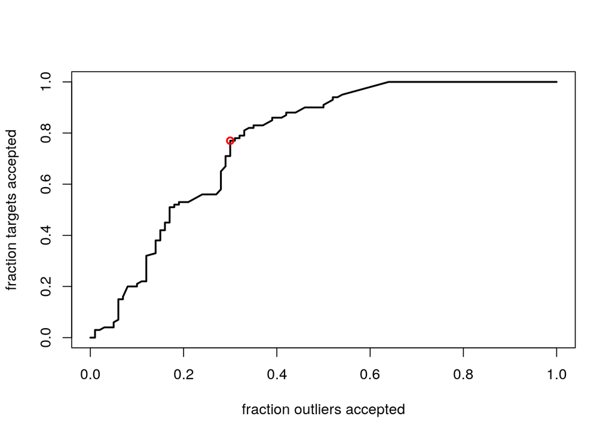

```r
#Plot ROC curve
y <- 1 - (error_inliers / sum(xval[,ncol(xval)]==0)) #frac targets accepted
x <- (error_outliers / sum(xval[,ncol(xval)]==1)) #frac outliers accepted
plot(x,y,type="l",lwd=2,xlab="fraction outliers accepted",ylab="fraction targets accepted") #ROC curve

#Find optimal point on ROC closest to upper left corner i.e. (0,1)
index <- which.min(x^2 + (y-1)^2)
points(x[index],y[index],pch=1,col="red",lwd=2)
```

```r
fracrej_opt <- R[index] #optimal fracrej
paste("Optimal fracrej =",fracrej_opt)
```

```
## [1] "Optimal fracrej = 0.182364729458918"
```

Use the optimal value of `fracrej` to call the classifier once more and evaluate its performance on the final test set using a confusion matrix and the measures derived from it such as sensitivity, specificity, etc.

```r
#run optimal model and test
if (!require("e1071")) install.packages("e1071")
if (!require("caret")) install.packages("caret")
library(e1071)
library(caret)

#run optimal model and test
out <- somocc(xtrn, xtst, gridSize= gridSize, fracrej = fracrej_opt, seed=1)
pred <- out[[1]]
cf <- confusionMatrix(factor(pred,levels=c(0,1)),factor(xtst[,ncol(xtst)],levels=c(0,1)))
print(cf)
```

```
## Confusion Matrix and Statistics
##
##           Reference
## Prediction  0  1
##          0 76 30
##          1 24 70
##
##                Accuracy : 0.73
##                  95% CI : (0.6628, 0.7902)
##     No Information Rate : 0.5
##     P-Value [Acc > NIR] : 2.837e-11
##
##                   Kappa : 0.46
##
##  Mcnemar's Test P-Value : 0.4962
##
##             Sensitivity : 0.7600
##             Specificity : 0.7000
##          Pos Pred Value : 0.7170
##          Neg Pred Value : 0.7447
##              Prevalence : 0.5000
##          Detection Rate : 0.3800
##    Detection Prevalence : 0.5300
##       Balanced Accuracy : 0.7300
##
##        'Positive' Class : 0
##
```

Finally, visualize the training set and decision boundary of the classifier. Also add the test set objects with different markers for inliers and outliers.

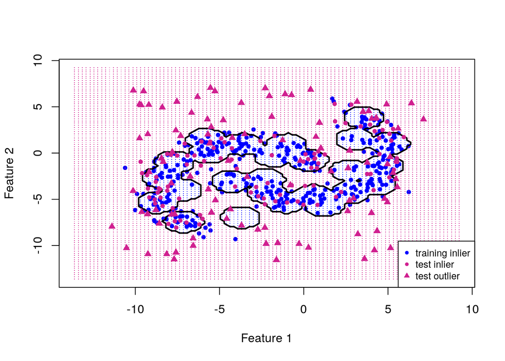

```r
#visualize decision boundary and training set
viz(data = xtrn, resolution = 100, classifier = "som",
    gridSize = gridSize, fracrej = fracrej_opt, seed = 1)

#add final test objects (inliers and outliers)
shape <- c(20,17) #dot, triangle
points(xtst[,1:2],col="violetred",pch=shape[xtst[,3]+1]) #add test objects
legend("bottomright",legend = c("training inlier","test inlier","test outlier"),
       col = c("blue","violetred","violetred"), pch = c(20,20,17), cex=0.8)
```